# AEB 3103, Principles of Economics

### Module 0: Kickstarter

Xinde “James” Ji

Assistant Professor, Natural Resource and Environmental Economics

Food and Resource Economics Department, Institute of Food and Agricultural Sciences

xji1@ufl.edu

Office hours: Tuesday/Thursday 2-3:30 pm

Location: Physically at my office (1181 McCarty A), and virtually at https://ufl.zoom.us/j/97284739634

In order to better know you guys, please fill out the following survey. I will share my answers with you in a bit :)

Link is here: https://forms.gle/ibpyJ1dGacdDGaBt9

[figure not shown]

# Here we go

- James Ji
- I go by James
- I am from Shanghai, China. I speak Chinese and English, and I’m learning Spanish.

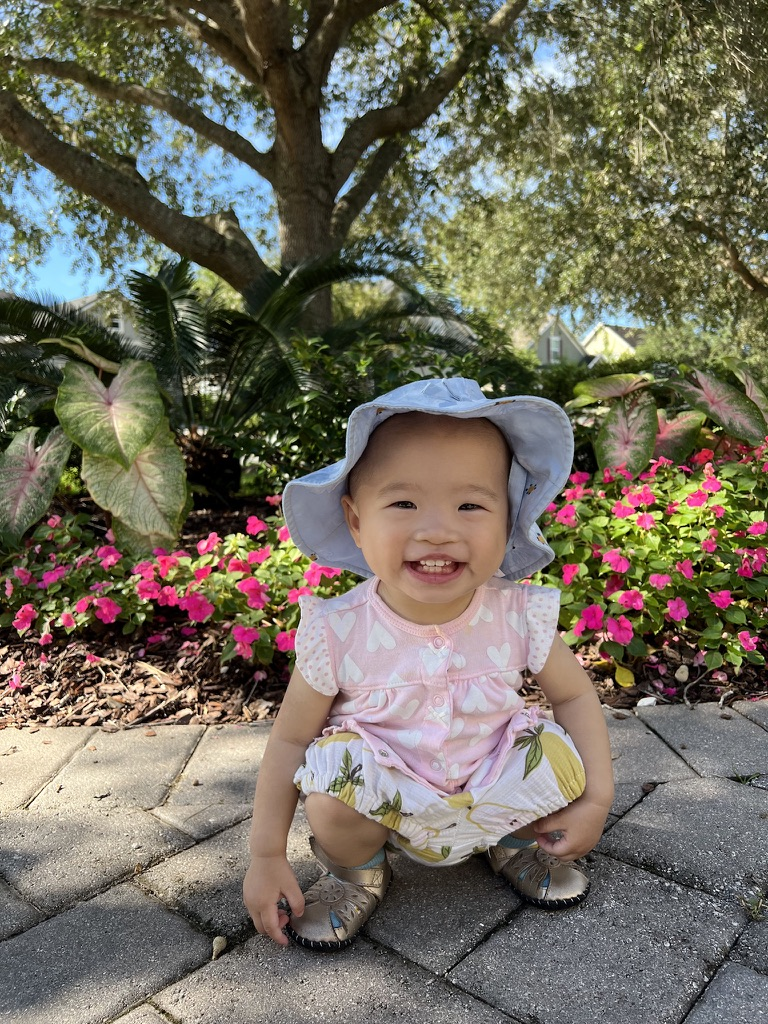

# Favorite book / TV show / movie

[figure not shown]

# Spiritual Animal

Here’s what I think I am:

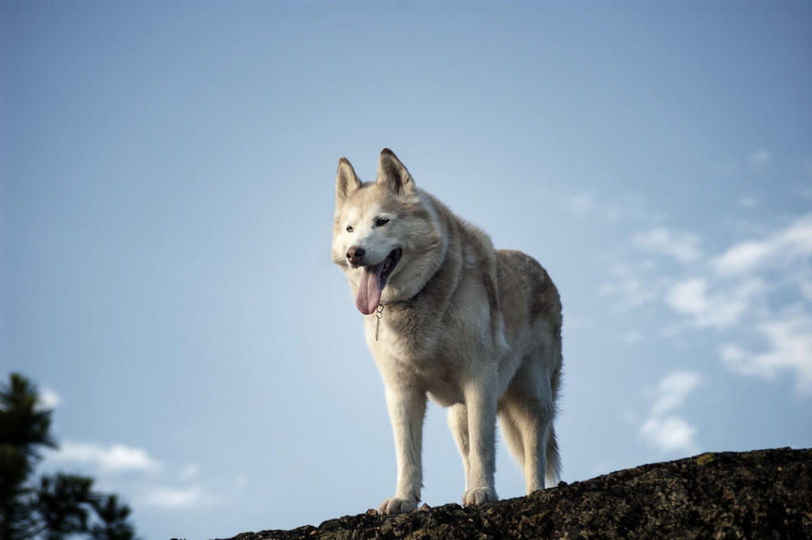

Here’s what my wife thinks I am:

[figure not shown]

# Plans after UF

That’s like, 35 years ahead of me

# Last Economics Course

I teach AEB 3103 (this class); Undergraduate Environmental Economics (AEB 3450); and PhD Environmental Economics (AEB 6933)

# What is economics?

Here I have a list of questions, and I want you to think about: do you think this is economics?

- What causes the business cycle (bubble and recession)?
- How human heart works?
- How fast do people drive on the I-75 highway?

# Are these economics?

- How much should bitcoin be worth?
- What causes an earthquake?
- How much do people eat at a buffet?

# Are these economics?

- Why are some countries rich and others poor?
- Should we ban off-shoring drilling?
- How many children should a family have?

# Are these economics?

- Who profits when gas price at the pump goes up?
- Sentencing every drug dealer to life without parole can end the opioid crisis.
- Should the Gators play a 4th down and 3 at the 50 yard line?

# What does economics study?

- Economics studies how humans make decisions **under various incentives and constraints**
  - How much to each at a buffet?
  - How do you decide how fast to drive on the I-75?

# How fast to drive on the I-75?

- Fuel costs (driving faster costs more fuel)
- The (opportunity) cost of time
- The (small) possibility of getting busted by the police if you speed
  - And all the trouble after that
- The (even smaller) possibility of a car crash
  - Driving faster = More deadly crash

# How much to each at a buffet?

- The cost of getting into the buffet
- The enjoyment one gets from consuming food

# What does economics study?

- Economics studies how humans make decisions **under various incentives and constraints**
- How these human decisions shape markets and societal outcomes
  - Who profits when gas price at the pump goes up?

# Who profits when gas price at the pump goes up?

[figure not shown]

# What does economics study?

- How humans make decisions **under various incentives and constraints**
- How these human decisions shape markets and the society collectively
- What are the effects of markets and/or governmental policies
  - Can sentencing every drug dealer to life without parole end the opioid crisis?

# Can sentencing every drug dealer to life without parole end the opioid crisis?

- For the drug dealers, they trade-off the reward (profits from dealing) with 1) the risk of getting caught; and 2) the penalty if getting caught
- Increasing sentencing makes drug dealing more risky
- They will ask higher risk-premium (i.e., rewards)
- “Market” prices for drugs become higher
- Does a higher drug price lower drug consumption?

# What does economics study?

- How humans make decisions **under various incentives and constraints**
- How these human decisions shape markets and the society collectively
- What are the effects of markets and/or governmental policies
- How does “the economy” work
  - What cause booms and busts?